# Função Theme e multiplos gráficos

Daniel Maurenza de Oliveira

https://github.com/dmaurenza/Curso-Intermediario-R

Nesta aula vamos aprender a usar a função theme(). A função theme() tem por objetivo ajustar/customizar elementos do gráficos não relacionados aos dados. Podemos ajustar o painel onde o gráfico esta inserido, o fundo do gráfico, a legenda, os títulos dos eixos, etc.

# Elementos da Aula

1. Funções theme
2. Multiplos gráficos

## Funções theme

Dentro da função theme(), utilizamos o argumento específico que desejamos alterar, juntamente com a função element() correspondente ao ajuste desejado. Para ilustrarmos mais didaticamente a relação entre a função theme() e a função element(), vamos nomear como “p” todo o gráfico da aula passada.

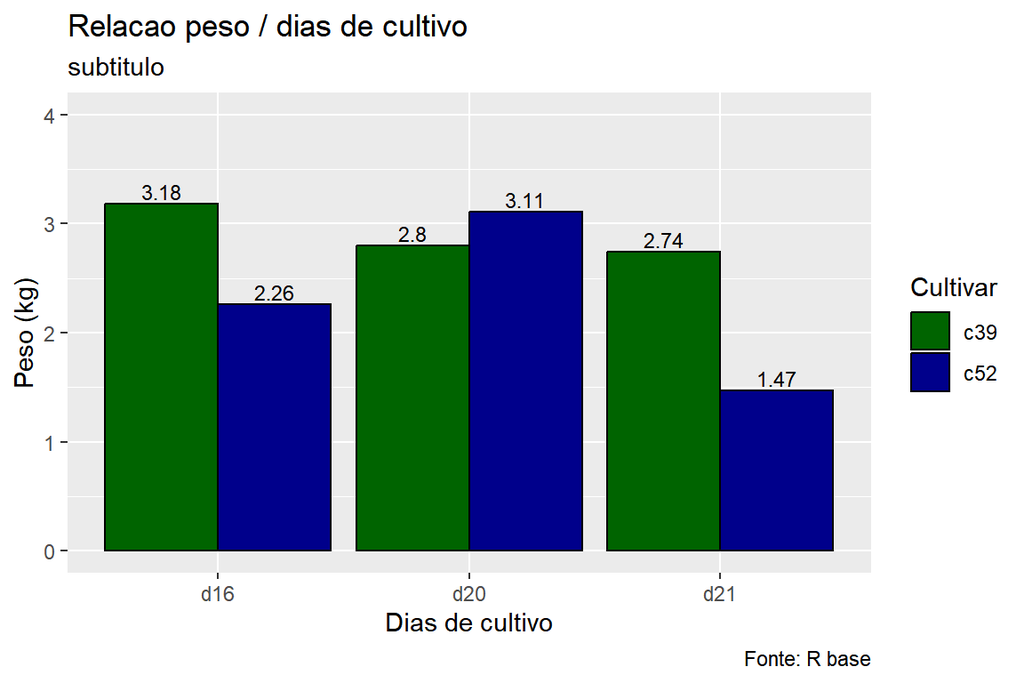

```r
library(ggplot2)
library(gcookbook)
p <- ggplot(data = cabbage_exp, aes(x = Date, y = Weight))+
  geom_col(aes(fill = Cultivar), position = "dodge", color = "black")+
  labs(x = "Dias de cultivo",
       y = "Peso (kg)",
       title = "Relacao peso / dias de cultivo",  # não esta configurado para aceitar acentuação
       subtitle = "subtitulo",
       caption = "Fonte: R base")+
  geom_text(aes(label = Weight, group = Cultivar),
            color = "black",
            size = 3,
            vjust = -0.3,
            position = position_dodge(0.9))+
  ylim(c(0, 4))+
  scale_fill_manual(values=c("darkgreen", "darkblue"))
p
```

Existem 4 elementos theme fundamentais.

1. element_text() - Modifica rótulos e cabeçarios. Podemos controlar a fonte, cor, tamanho, ajustes horizontais e verticas

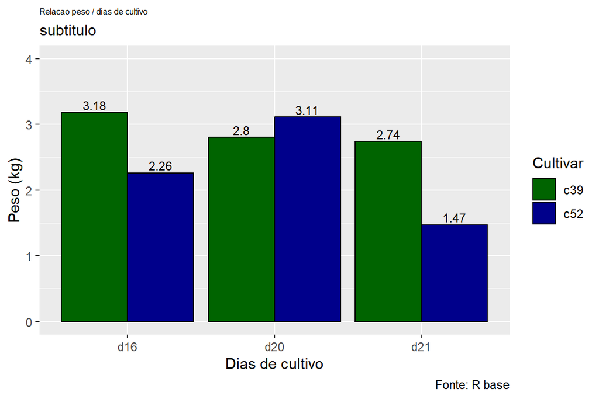

```r
p + theme(plot.title = element_text(size = 6))
```

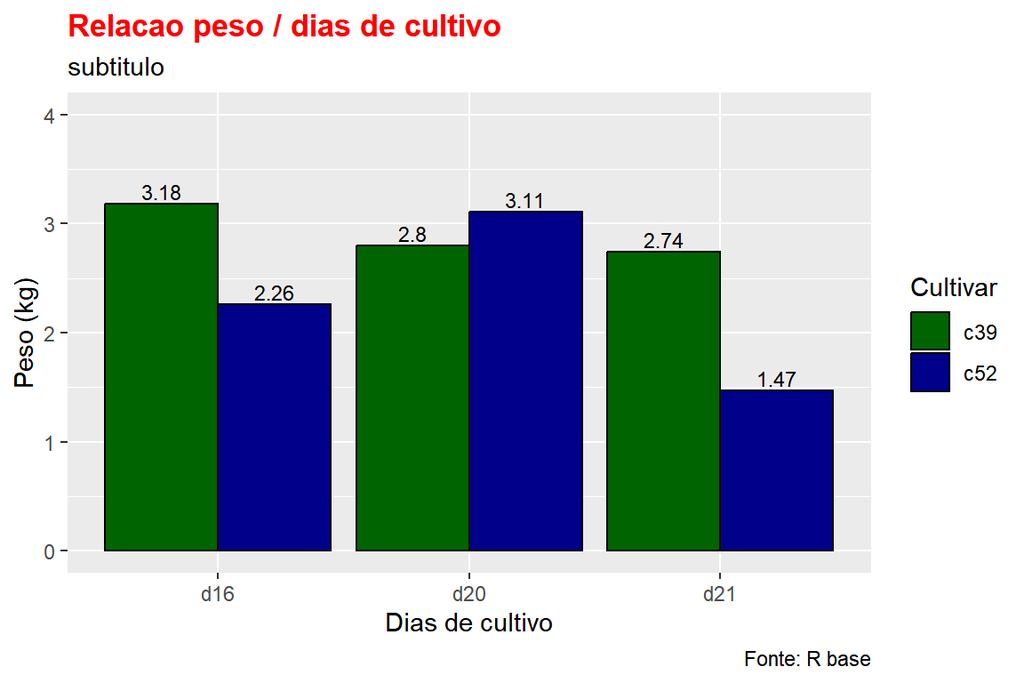

```r
p + theme(plot.title = element_text(face = "bold", colour = "red"))
```

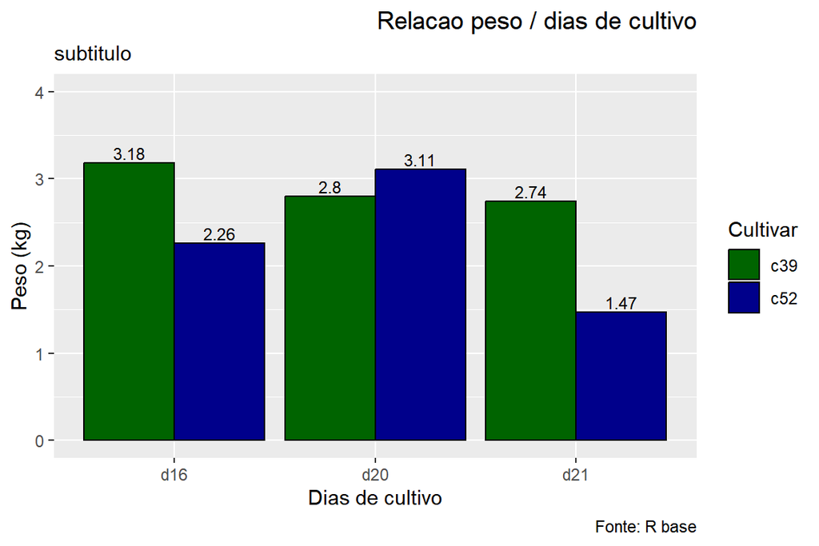

```r
p + theme(plot.title = element_text(hjust = 1))
```

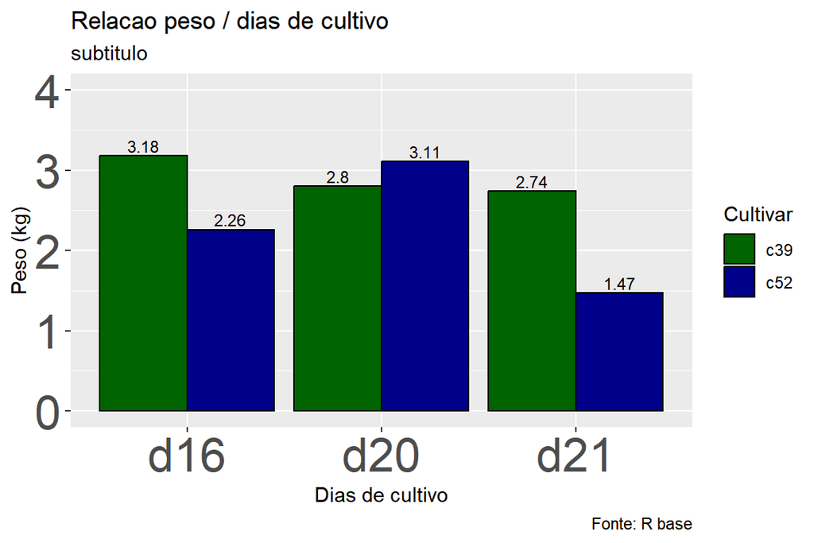

```r
p + theme(axis.text = element_text(size = 25))
```

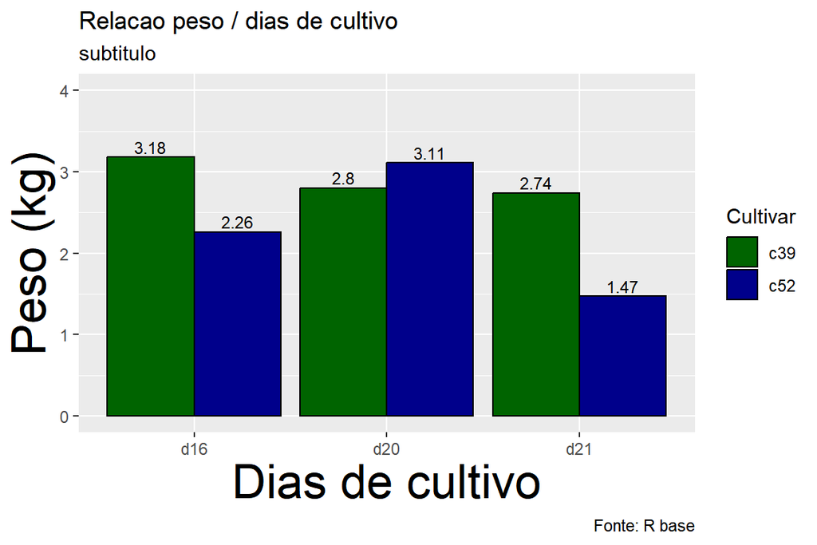

```r
p + theme(axis.title = element_text(size = 25))
```

2. element_line() - Modifica parâmetros das linhas, tais como cor, tamanho e estilo

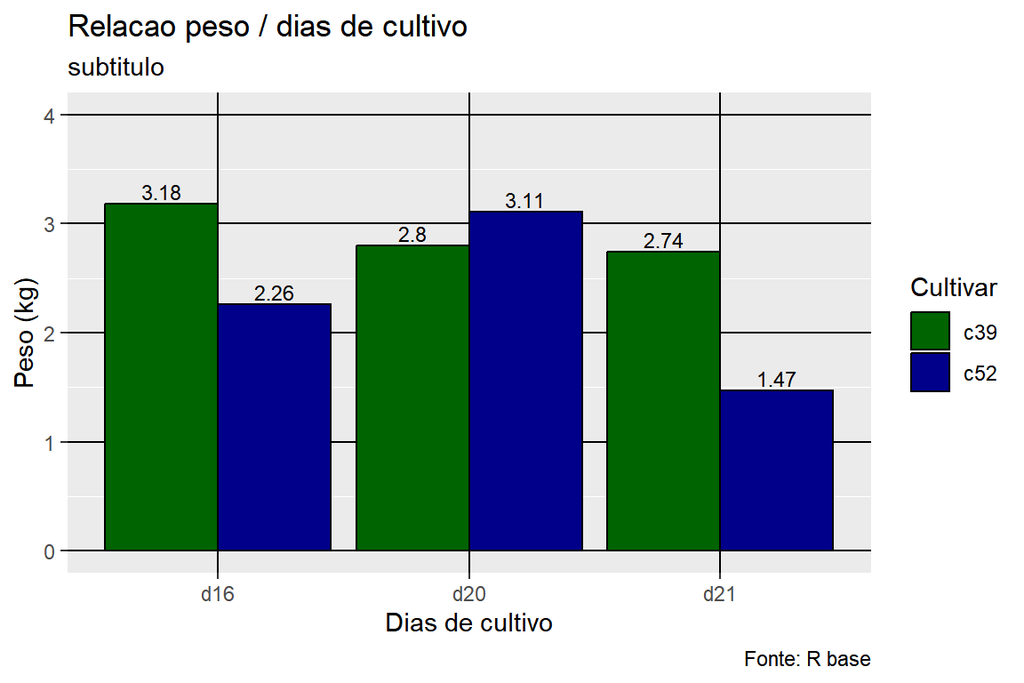

```r
p + theme(panel.grid.major = element_line(colour = "black"))
```

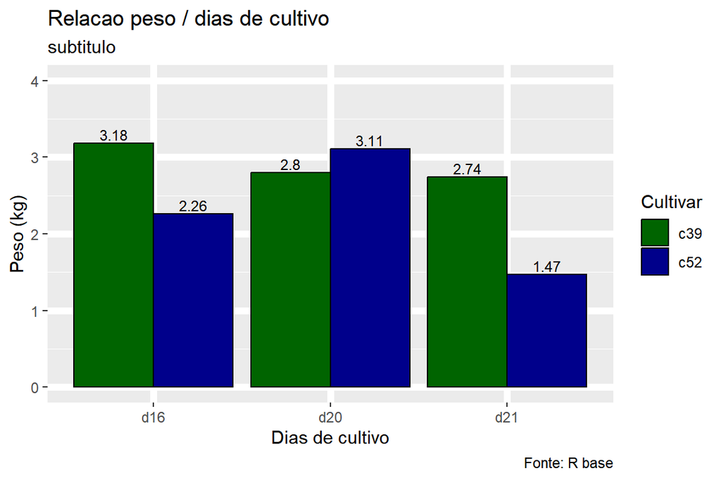

```r
p + theme(panel.grid.major = element_line(linewidth = 2))
```

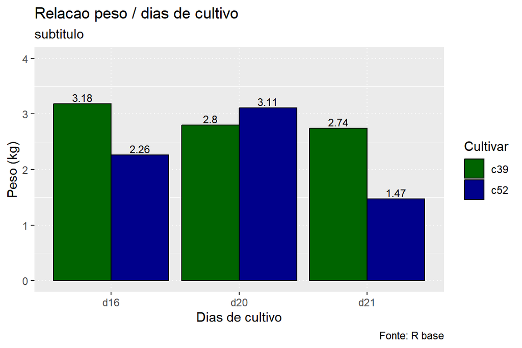

```r
p + theme(panel.grid.major = element_line(linetype = "dotted"))
```

3. element_rect() - Modifica ajustes de retangulos, muito utilizado para modificar o fundo dos gráficos, e outros parâmetros de área

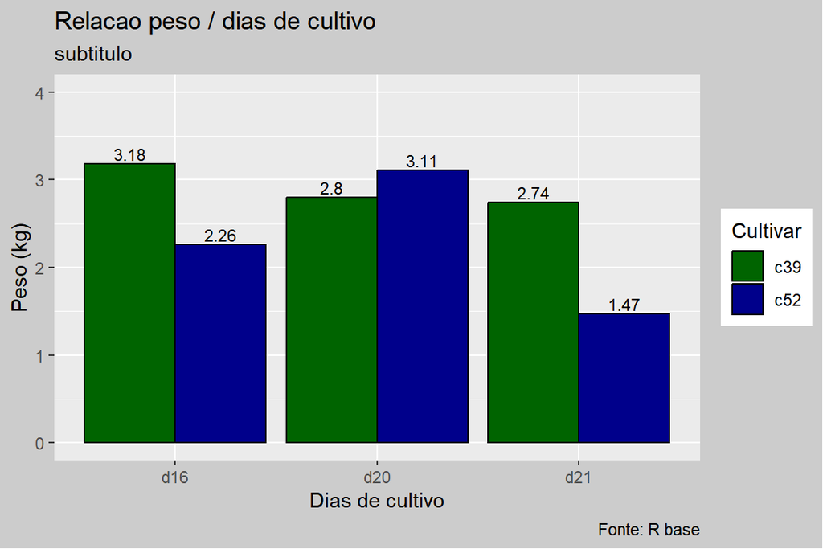

```r
p + theme(plot.background = element_rect(fill = "grey80", colour = NA))
```

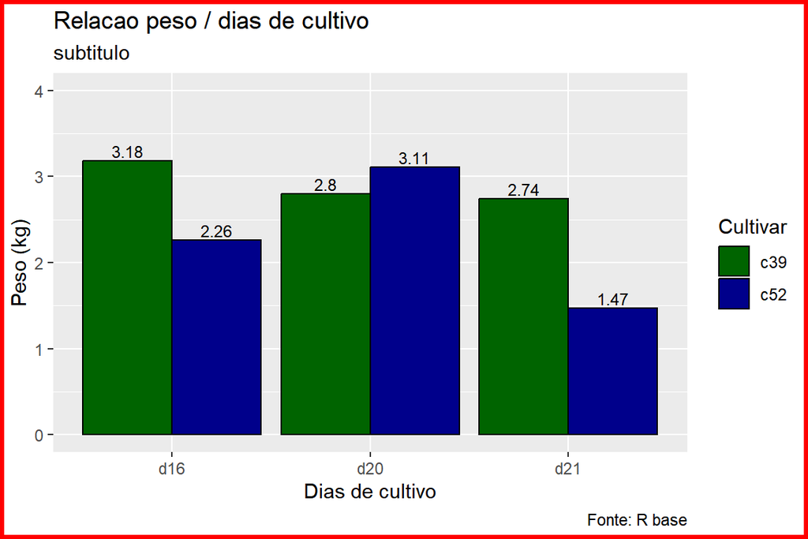

```r
p + theme(plot.background = element_rect(colour = "red", size = 2))
```

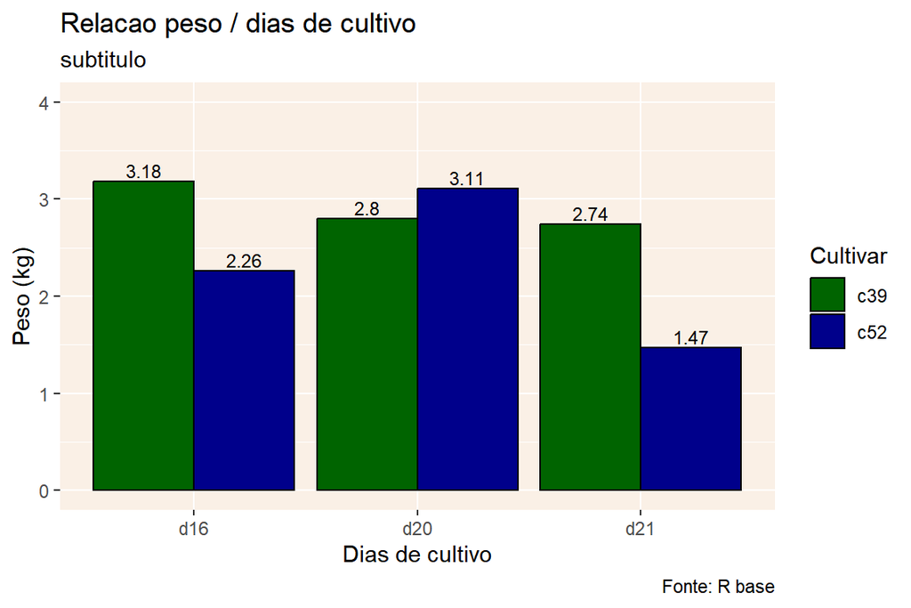

```r
p + theme(panel.background = element_rect(fill = "linen"))
```

4. element_blank() - Modifica para “Nada”. Usado quando não queremos fazer ajustes ou não queremos alocar espaços

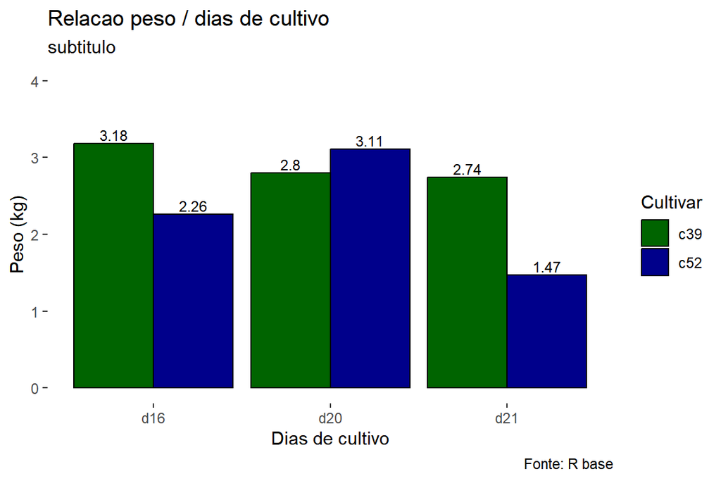

```r
p + theme(panel.background = element_blank())
```

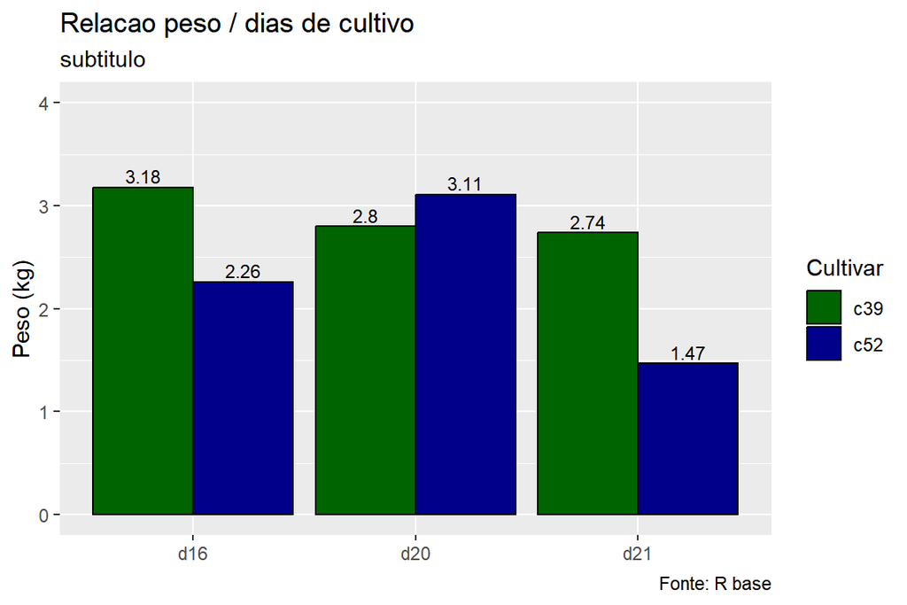

```r
p + theme(axis.title.x = element_blank())
```

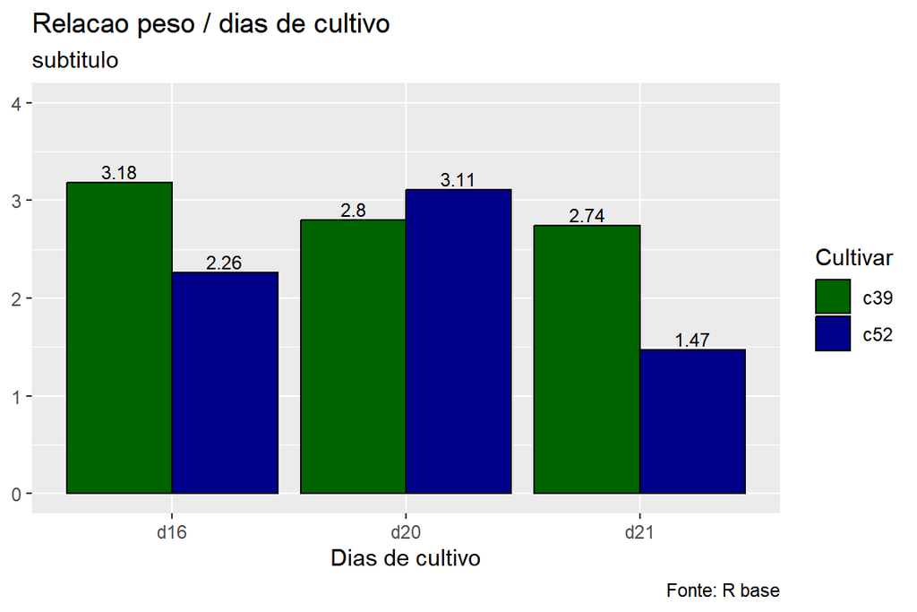

```r
p + theme(axis.title.y = element_blank())
```

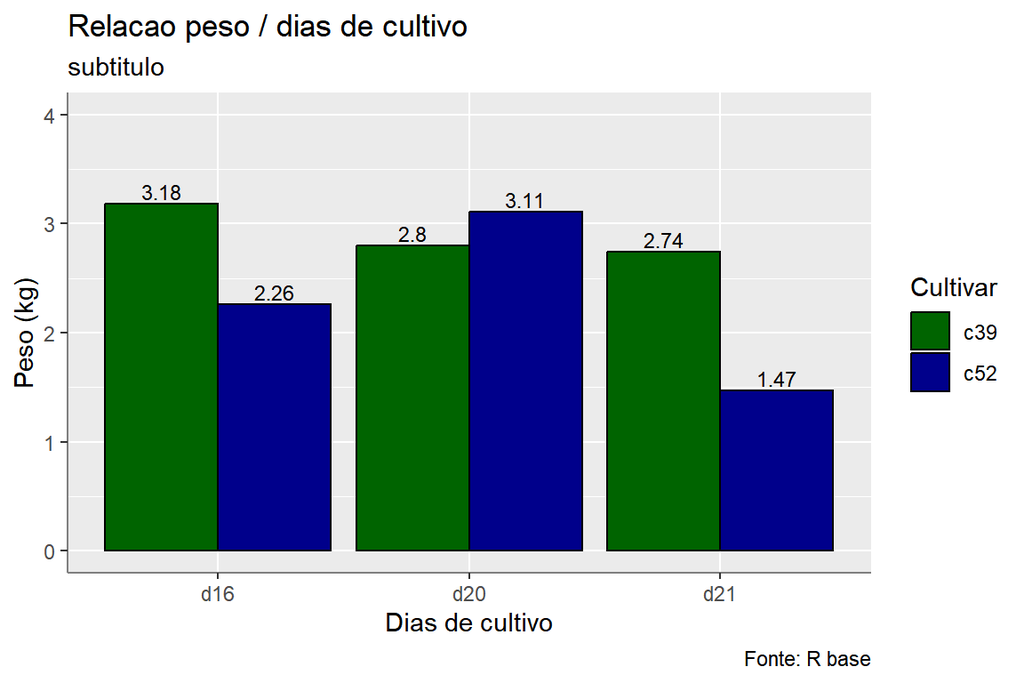

```r
p + theme(axis.line = element_line(colour = "grey50"))
```

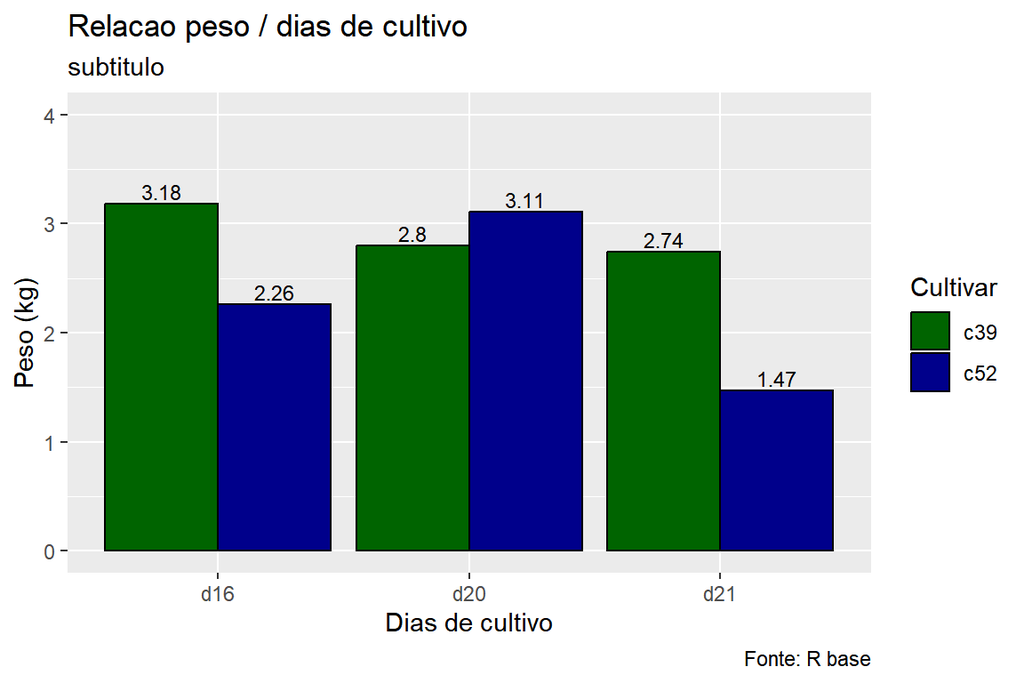

```r
p + theme(axis.line = element_blank())
```

Similar ao que vimos anteriormente, podemos incluir varios argumentos da função theme no mesmo gráfico

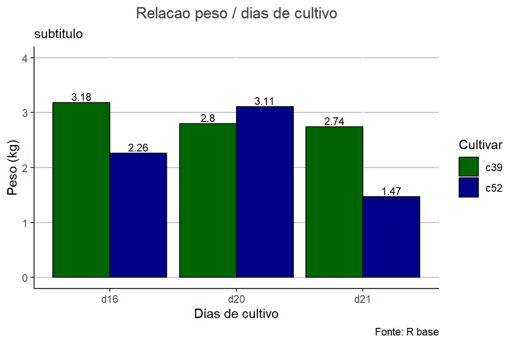

```r
p + theme(plot.title = element_text(hjust = 0.5, colour = "grey25"),
          panel.grid.major.y = element_line(colour = "grey"),
          panel.grid.minor = element_blank(),
          panel.background = element_blank(),
          axis.line = element_line(colour = "black"),
          legend.position = "right")
```

Veja em help a diversidade de funcionalidades que a função theme fornece, e [*aqui*](https://ggplot2-book.org/polishing.html#theme-elements) uma lista de argumentos que podem ser usados na função theme(), juntamente com a função element() correspondente

## Multiplos gráficos

Porvezes, quando apresentamos os resultados das análises dos dados, queremos apresentar vários gráficos inter-relacionados ao mesmo tempo. O ggplot2 possui a função “faced_wrap()”, que elegantemente desenha uma seguência de gráficos.

Para usarmos a função “faced_wrap()”, basta adicionar uma nova camada, incluindo a coluna da tabela original que representa os diferentes gráficos. Vamos utilizar os dados “gapminder”, pois eles fornecem informações suficiente para exemplificar.

```r
library(gapminder)
```

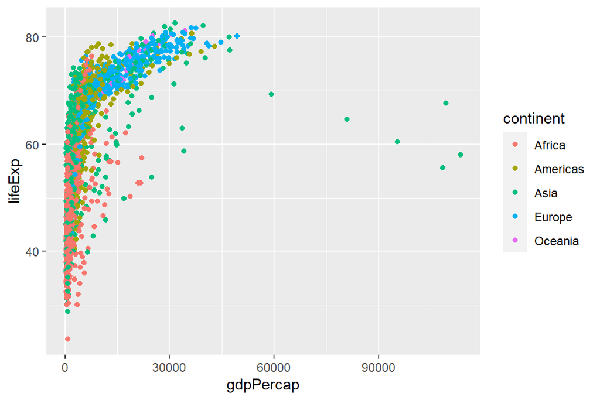

```r
p <- ggplot(data = gapminder, aes(x = gdpPercap, y = lifeExp))
p +
  geom_point(aes(color = continent))
```

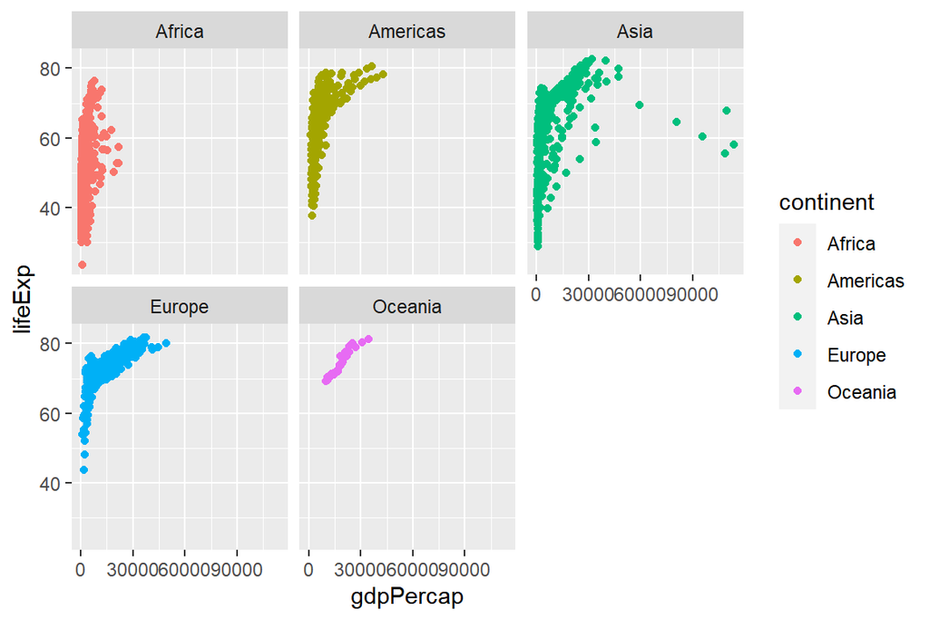

```r
p <- ggplot(data = gapminder, aes(x = gdpPercap, y = lifeExp))
p +
  geom_point(aes(color = continent))+
  facet_wrap(~continent)
```

Podemos definir a disposição dos gráficos indicando o número de linhas ou colunas,

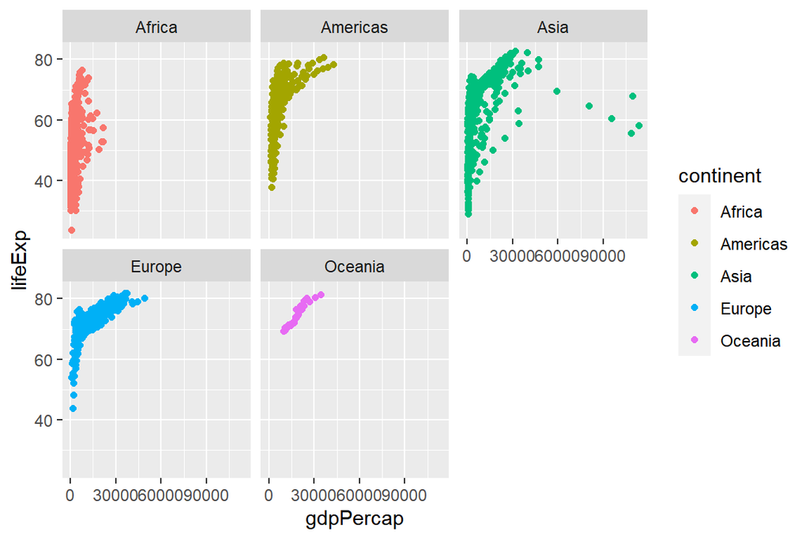

```r
p +
  geom_point(aes(color = continent))+
  facet_wrap(~continent, nrow = 2)
```

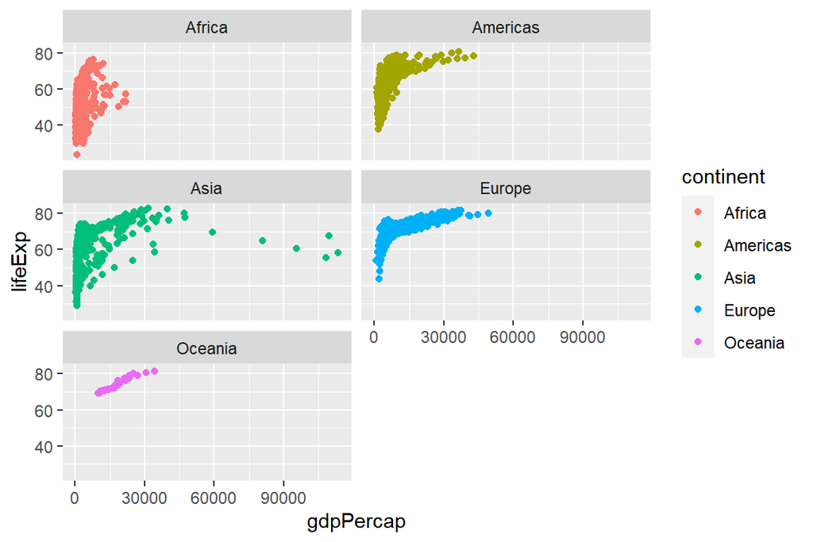

```r
p +
  geom_point(aes(color = continent))+
  facet_wrap(~continent, ncol = 2)
```

Por fim, vamos ver como armazenamos em arquivo o gráfico criado. Para tanto, usamos a função ggsave(). Esta função sempre armazenará o último gráfico feito usando o pacote ggplot2. Basta indicar o “caminho” onde o arquivo de figura deve ser guardado, adicionando a extensão do arquivo (“eps”, “ps”, “tex” (pictex), “pdf”, “jpeg”, “tiff”, “png”, “bmp”, “svg” or “wmf”).

É bastante útil a habilidade do ggplot2 de poder definir a altura e largura da figura, através dos argumentos “width” e “height”

```r
ggsave("Figuras/gapminder_continentes.png", width = 5, height = 5)
```

## Exercícios

1. Copie seu script da aula anterior, onde fizemos gráficos sobre a relação peso idade para o sexo masculino e feminino. Faça pelo menos 1 ajuste para cada tipo da função element().
2. Faça uma figura de gráficos multiplos, onde cada gráfico representará a relação peso idade para os alunos de cada semestre.
3. Armazene seu gráfico em uma pasta chamada “Figura”, ajustando altura e largura.